# RESI for gam fits: resampling evaluation on the insurance data

# Design

`tests/run_gam_insurance.R` follows `insurancePlasmodeSim()` (the lm/glm evaluation). The population is `RESI::insurance` (N = 1338). Each replicate draws $n \in \{200, 500, 1000, 2000, 5000\}$ rows with replacement (500 replicates). It also adds a pure-noise covariate $z \sim U(0, 1)$, which makes `s(z)` a null smooth. The model is

```
log10(charges) ~ smoker + sex + region + children + s(age) + s(bmi)
                 + s(age, by = smoker) + s(bmi, by = smoker) + s(z)
```

- `smoker` is an ordered factor, so `s(age):smokeryes` and `s(bmi):smokeryes` are the smoker minus non-smoker difference curves. These are the nonlinear interactions.
- All smooths are cubic regression splines (`bs = "cr"`) with $k \in \{10, 20\}$. The knots are fixed from the full data, so the basis is the same in every replicate.
- Fits use `gam(method = "REML")`, penalized (mgcv default) or unpenalized (`fx = TRUE`). RESI comes from `resi_pe()`:
  - smooth terms: `f2S(F, Ref.df, n - sum(edf), n)`;
  - factor terms: `f2S(F, df, ...)`;
  - coefficients: `t2S`.

**Target.** The target is the full-data projection onto the same basis (unpenalized, $\sigma^2$ = mean squared residual). This is the regression-spline target T2($k$) of `notes/resi_gam.qmd` and the analog of the lm convention. Under pairs resampling, the population’s basis-free regression function is the empirical one, which is nearly saturated in `bmi`. T1 is therefore not a useful target here, and the two values of $k$ show how much the target depends on the basis. $S$ for `s(z)` is exactly 0.

Full-data targets for the ANOVA-table terms.

| term | S_true, k = 10 | S_true, k = 20 |
| --- | --- | --- |
| smoker | 1.626 | 1.597 |
| sex | 0.111 | 0.108 |
| region | 0.158 | 0.160 |
| children | 0.292 | 0.289 |
| s(age) | 1.380 | 1.385 |
| s(bmi) | 0.078 | 0.116 |
| s(age):smokeryes | 0.504 | 0.503 |
| s(bmi):smokeryes | 0.366 | 0.371 |
| s(z) | 0.000 | 0.000 |

# Null check: `s(z)`

Rejection rate at 0.05 and mean RESI for the null smooth s(z).

| estimator | k | n | reject | S |
| --- | --- | --- | --- | --- |
| mgcv | 10 | 200 | 0.058 | 0.034 |
| mgcv | 10 | 500 | 0.044 | 0.018 |
| mgcv | 10 | 1000 | 0.054 | 0.015 |
| mgcv | 10 | 2000 | 0.060 | 0.011 |
| mgcv | 10 | 5000 | 0.068 | 0.007 |
| mgcv | 20 | 200 | 0.058 | 0.035 |
| mgcv | 20 | 500 | 0.044 | 0.018 |
| mgcv | 20 | 1000 | 0.054 | 0.015 |
| mgcv | 20 | 2000 | 0.060 | 0.010 |
| mgcv | 20 | 5000 | 0.066 | 0.007 |
| unpenalized | 10 | 200 | 0.054 | 0.055 |
| unpenalized | 10 | 500 | 0.032 | 0.030 |
| unpenalized | 10 | 1000 | 0.034 | 0.024 |
| unpenalized | 10 | 2000 | 0.070 | 0.018 |
| unpenalized | 10 | 5000 | 0.046 | 0.011 |
| unpenalized | 20 | 200 | 0.060 | 0.071 |
| unpenalized | 20 | 500 | 0.032 | 0.040 |
| unpenalized | 20 | 1000 | 0.048 | 0.030 |
| unpenalized | 20 | 2000 | 0.058 | 0.023 |
| unpenalized | 20 | 5000 | 0.052 | 0.013 |

# Calibration

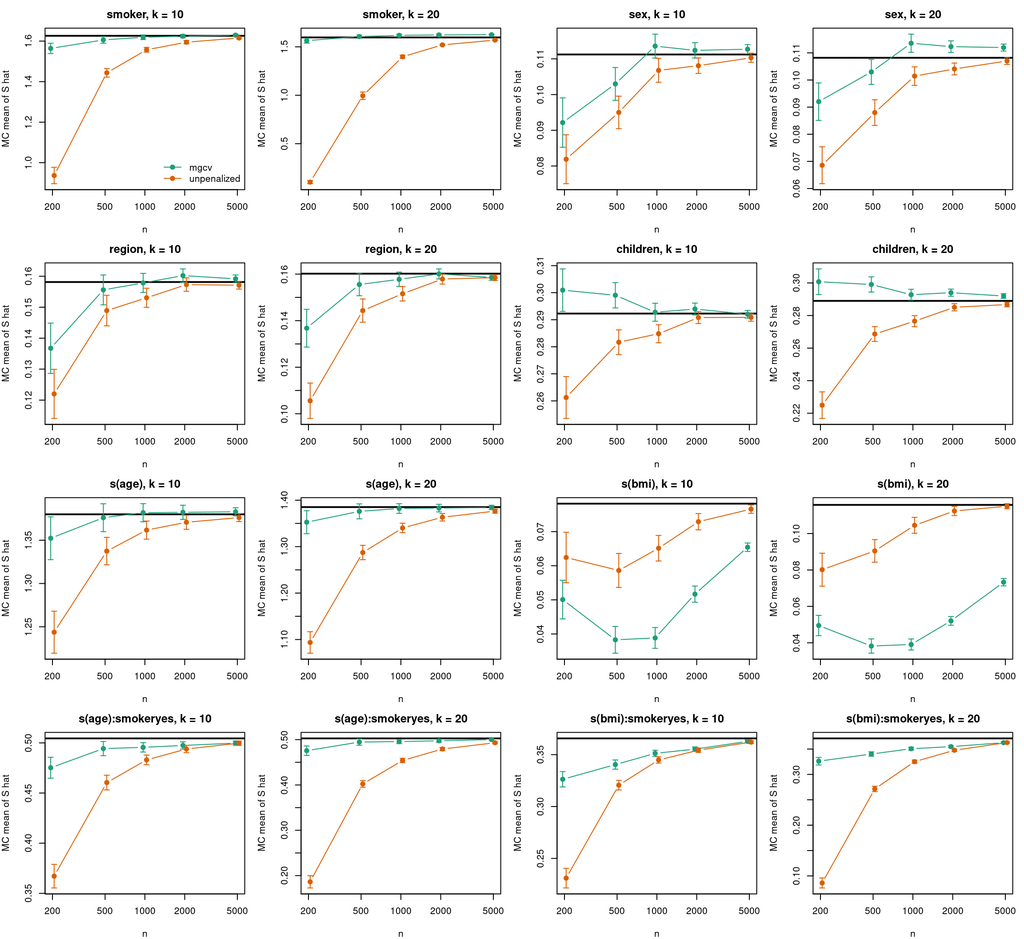

Black line: full-data target. Points: MC mean ± 2 MC SE.

Relative bias of the MC mean of the RESI estimate.

| term | k | estimator | n = 200 | n = 1000 | n = 500 | n = 2000 | n = 5000 |
| --- | --- | --- | --- | --- | --- | --- | --- |
| smoker | 10 | mgcv | -0.038 | -0.004 | -0.012 | -0.001 | 0.002 |
| sex | 10 | mgcv | -0.171 | 0.021 | -0.074 | 0.010 | 0.013 |
| region | 10 | mgcv | -0.135 | -0.002 | -0.016 | 0.013 | 0.007 |
| children | 10 | mgcv | 0.030 | 0.002 | 0.023 | 0.006 | -0.001 |
| s(age) | 10 | mgcv | -0.020 | 0.001 | -0.003 | 0.002 | 0.002 |
| s(bmi) | 10 | mgcv | -0.360 | -0.503 | -0.510 | -0.339 | -0.163 |
| s(age):smokeryes | 10 | mgcv | -0.058 | -0.018 | -0.020 | -0.014 | -0.009 |
| s(bmi):smokeryes | 10 | mgcv | -0.108 | -0.039 | -0.069 | -0.028 | -0.008 |
| smoker | 20 | mgcv | -0.021 | 0.013 | 0.005 | 0.016 | 0.018 |
| sex | 20 | mgcv | -0.150 | 0.049 | -0.048 | 0.038 | 0.035 |
| region | 20 | mgcv | -0.146 | -0.015 | -0.029 | -0.001 | -0.010 |
| children | 20 | mgcv | 0.041 | 0.013 | 0.035 | 0.017 | 0.010 |
| s(age) | 20 | mgcv | -0.023 | -0.002 | -0.007 | -0.002 | -0.001 |
| s(bmi) | 20 | mgcv | -0.572 | -0.663 | -0.670 | -0.551 | -0.367 |
| s(age):smokeryes | 20 | mgcv | -0.054 | -0.014 | -0.016 | -0.010 | -0.005 |
| s(bmi):smokeryes | 20 | mgcv | -0.121 | -0.055 | -0.083 | -0.044 | -0.023 |
| smoker | 10 | unpenalized | -0.424 | -0.042 | -0.112 | -0.019 | -0.007 |
| sex | 10 | unpenalized | -0.264 | -0.040 | -0.146 | -0.028 | -0.008 |
| region | 10 | unpenalized | -0.228 | -0.032 | -0.058 | -0.005 | -0.007 |
| children | 10 | unpenalized | -0.106 | -0.025 | -0.036 | -0.005 | -0.005 |
| s(age) | 10 | unpenalized | -0.099 | -0.013 | -0.031 | -0.007 | -0.003 |
| s(bmi) | 10 | unpenalized | -0.202 | -0.167 | -0.250 | -0.068 | -0.021 |
| s(age):smokeryes | 10 | unpenalized | -0.272 | -0.043 | -0.087 | -0.021 | -0.009 |
| s(bmi):smokeryes | 10 | unpenalized | -0.368 | -0.057 | -0.123 | -0.031 | -0.010 |
| smoker | 20 | unpenalized | -0.935 | -0.125 | -0.377 | -0.048 | -0.017 |
| sex | 20 | unpenalized | -0.366 | -0.062 | -0.187 | -0.038 | -0.011 |
| region | 20 | unpenalized | -0.341 | -0.054 | -0.099 | -0.014 | -0.011 |
| children | 20 | unpenalized | -0.222 | -0.043 | -0.070 | -0.014 | -0.008 |
| s(age) | 20 | unpenalized | -0.210 | -0.032 | -0.071 | -0.016 | -0.006 |
| s(bmi) | 20 | unpenalized | -0.308 | -0.097 | -0.218 | -0.029 | -0.006 |
| s(age):smokeryes | 20 | unpenalized | -0.629 | -0.097 | -0.200 | -0.047 | -0.019 |
| s(bmi):smokeryes | 20 | unpenalized | -0.768 | -0.123 | -0.268 | -0.063 | -0.022 |

Mean effective degrees of freedom of the penalized smooths (k - 1 is the maximum).

| term | k | n = 200 | n = 500 | n = 1000 | n = 2000 | n = 5000 |
| --- | --- | --- | --- | --- | --- | --- |
| s(age) | 10 | 2.05 | 2.88 | 3.85 | 4.79 | 6.08 |
| s(bmi) | 10 | 1.57 | 1.77 | 2.18 | 3.03 | 4.55 |
| s(age):smokeryes | 10 | 1.29 | 1.75 | 2.35 | 3.03 | 4.33 |
| s(bmi):smokeryes | 10 | 1.52 | 2.78 | 4.20 | 5.64 | 7.15 |
| s(age) | 20 | 2.09 | 2.94 | 4.02 | 5.24 | 8.38 |
| s(bmi) | 20 | 1.58 | 1.81 | 2.22 | 3.19 | 6.83 |
| s(age):smokeryes | 20 | 1.30 | 1.75 | 2.37 | 3.06 | 4.49 |
| s(bmi):smokeryes | 20 | 1.52 | 2.79 | 4.31 | 6.07 | 8.77 |